# Previsão de Demanda

A previsão de demanda irá isolar os produtos para realizar as previsões de forma isolada. Assim, essa seção será dividida entre os produtos MO0021, MO0091 e MO1401.

## Produto MO0021

Será realizada uma previsão para cada um dos centros de distribuição: São Paulo, Tocantins e Amazonas.

### Centro de São Paulo

A Figura @ref(fig:MO0021SP001) apresenta o histórico de vendas para este centro.

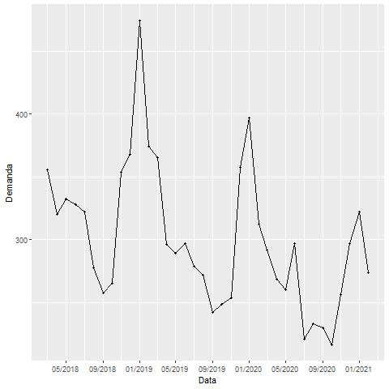

Histório do produto MO0021 em São Paulo

A Figura @ref(fig:MO0021SP002) apresenta a série de forma decomposta em tendência, sazonalidade e restante. Percebe-se pela figura que há uma tendência negativa (queda da demanda ao longo do tempo), com uma sazonalidade bastante clara.

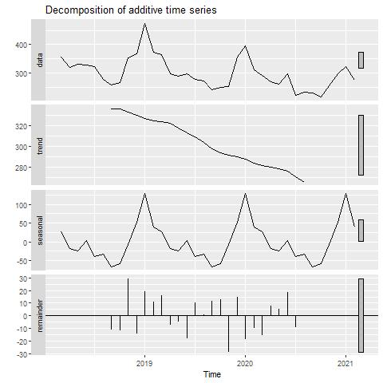

Série decomposta do produto MO0021 em São Paulo

A aplicação dos métodos Suavização Exponencial (SE), ARIMA e Redes Neurais Autoregresivas (RNA) retornou os MAPE’s apresentados na Tabela @ref(tab:TABMO0021SP001).

Comparação entre os modelos

| Método | SE | ARIMA | RNA |
| --- | --- | --- | --- |
| MAPE | 3.98 | 5.37 | 4.23 |

Portanto, por ter o menor MAPE, o método utilizado para a previsão é o de Suavização Exponencial. Ademais, a Figura @ref(fig:MO0021SP003) apresenta a análise de resíduos. Como esperado, os resíduos variam em torno de zero sem tendência positiva ou negativa, o parâmetro ACF (fator de autocorrelação) mostra resultados positivos uma vez que os resíduos não apresentam autocorrelação (as linhas pretas não extrapolam os limites em azul) e os erros apresentam uma característica normal.

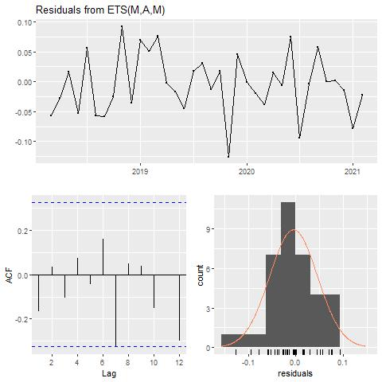

Resíduos da previsão para o produto MO0021 em São Paulo

A Tabela @ref(tab:TABMO0021SP002) apresenta os valores previstos para o ano de 2021.

Previsão de demanda do produto MO0021 para São Paulo

| 03/21 | 04/21 | 05/21 | 06/21 | 07/21 | 08/21 | 09/21 | 10/21 | 11/21 | 12/21 |
| --- | --- | --- | --- | --- | --- | --- | --- | --- | --- |
| 265.82 | 231.47 | 228.68 | 240.97 | 211.92 | 203.22 | 188.37 | 186.82 | 221.32 | 259.74 |

O gráfico da previsão está apresentado na Figura @ref(fig:MO0021SP004).

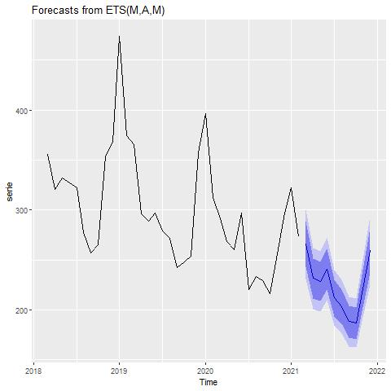

Previsão para o produto MO0021 em São Paulo

### Centro de Tocantins

A Figura @ref(fig:MO0021TO001) apresenta o histórico de vendas para este centro.

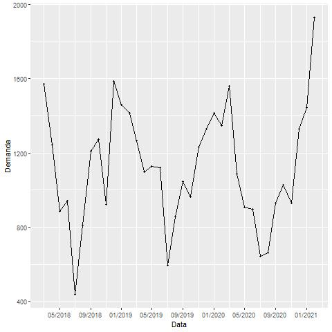

Histório do produto MO0021 em Tocantins

A Figura @ref(fig:MO0021TO002) apresenta a série de forma decomposta em tendência, sazonalidade e restante. Percebe-se pela figura que há uma tendência negativa (diminuição da demanda ao longo do tempo) com uma sazonalidade bastante clara.

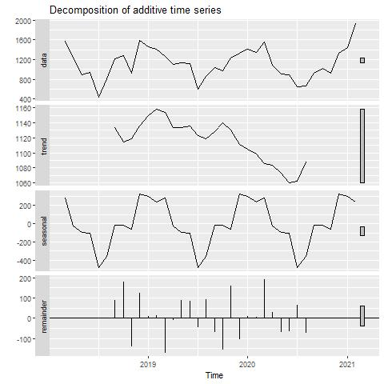

Série decomposta do produto MO0021 em Tocantins

A aplicação dos métodos Suavização Exponencial (SE), ARIMA e Redes Neurais Autoregresivas (RNA) retornou os MAPE’s apresentados na Tabela @ref(tab:TABMO0021TO001).

Comparação entre os modelos

| Método | SE | ARIMA | RNA |
| --- | --- | --- | --- |
| MAPE | 10.67 | 11.05 | 8.23 |

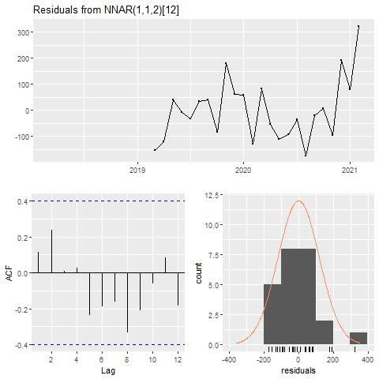

Resíduos da previsão para o produto MO0021 em Tocantins

A Tabela @ref(tab:TABMO0021TO002) apresenta os valores previstos para o ano de 2021.

Previsão de demanda do produto MO0021 para Tocantins

| 03/21 | 04/21 | 05/21 | 06/21 | 07/21 | 08/21 | 09/21 | 10/21 | 11/21 | 12/21 |
| --- | --- | --- | --- | --- | --- | --- | --- | --- | --- |
| 1439.5 | 885.83 | 1002.2 | 1059.4 | 523.08 | 788.06 | 918.39 | 987.14 | 1060.77 | 1166.8 |

O gráfico da previsão está apresentado na Figura @ref(fig:MO0021TO004).

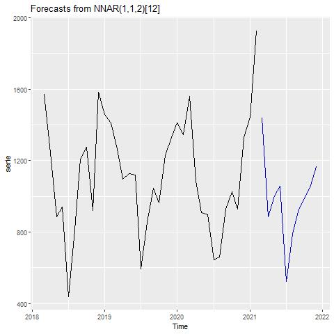

Previsão para o produto MO0021 em Tocantins

### Centro do Amazonas

A Figura @ref(fig:MO0021AM001) apresenta o histórico de vendas para este centro.

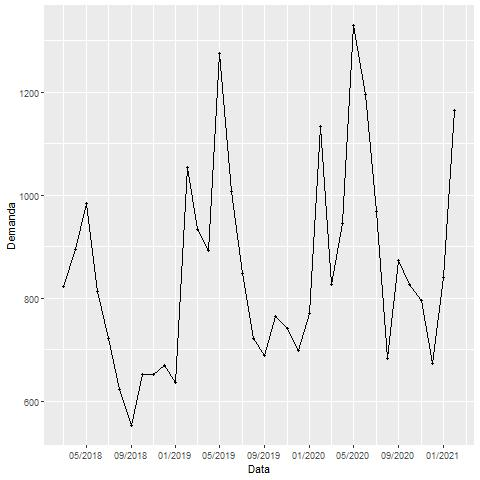

Histório do produto MO0021 no Amazonas

A Figura @ref(fig:MO0021AM002) apresenta a série de forma decomposta em tendência, sazonalidade e restante. Percebe-se pela figura que há uma tendência positiva (aumento da demanda ao longo do tempo) com uma sazonalidade bastante clara.

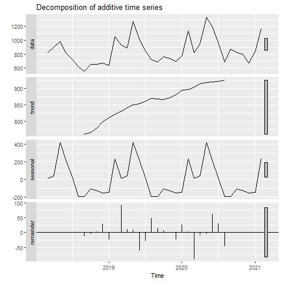

Série decomposta do produto MO0021 no Amazonas

A aplicação dos métodos Suavização Exponencial (SE), ARIMA e Redes Neurais Autoregresivas (RNA) retornou os MAPE’s apresentados na Tabela @ref(tab:TABMO0021AM001).

Comparação entre os modelos

| Método | SE | ARIMA | RNA |
| --- | --- | --- | --- |
| MAPE | 6.32 | 4.84 | 5.55 |

Portanto, por ter o menor MAPE, o método utilizado para a previsão é o ARIMA. Ademais, a Figura @ref(fig:MO0021AM003) apresenta a análise de resíduos. Como esperado, os resíduos variam em torno de zero sem tendência positiva ou negativa, o parâmetro ACF (fator de autocorrelação) mostra resultados positivos uma vez que os resíduos não apresentam autocorrelação (as linhas pretas não extrapolam os limites em azul) e os erros apresentam uma característica normal.

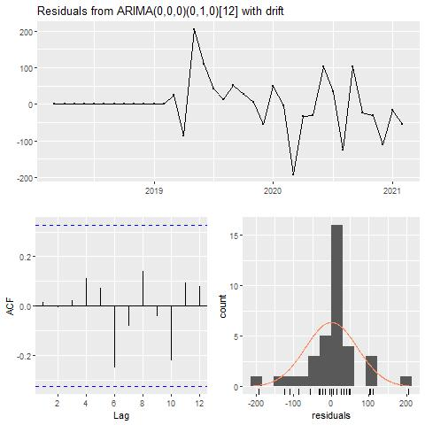

Resíduos da previsão para o produto MO0021 no Amazonas

A Tabela @ref(tab:TABMO0021AM002) apresenta os valores previstos para o ano de 2021.

Previsão de demanda do produto MO0021 para Amazonas

| 03/21 | 04/21 | 05/21 | 06/21 | 07/21 | 08/21 | 09/21 | 10/21 | 11/21 | 12/21 |
| --- | --- | --- | --- | --- | --- | --- | --- | --- | --- |
| 910.99 | 1030.59 | 1414.69 | 1281.29 | 1053.59 | 768.39 | 959.29 | 910.99 | 881.09 | 759.19 |

O gráfico da previsão está apresentado na Figura @ref(fig:MO0021AM004).

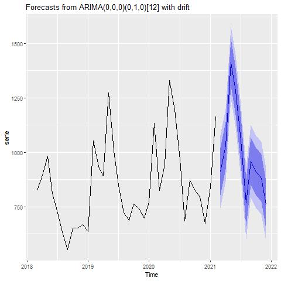

Previsão para o produto MO0021 no Amazonas

## Produto MO0091

Será realizada uma previsão para cada um dos centros de distribuição: São Paulo, Tocantins e Amazonas.

### Centro de São Paulo

A Figura @ref(fig:MO0091SP001) apresenta o histórico de vendas para este centro.

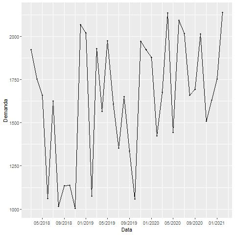

Histório do produto MO0091 em São Paulo

A Figura @ref(fig:MO0091SP002) apresenta a série de forma decomposta em tendência, sazonalidade e restante. Percebe-se pela figura que há uma tendência positiva (aumento da demanda ao longo do tempo) com uma sazonalidade bastante clara.

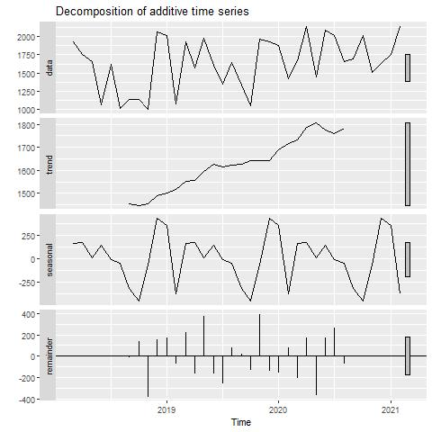

Série decomposta do produto MO0091 em São Paulo

A aplicação dos métodos Suavização Exponencial (SE), ARIMA e Redes Neurais Autoregresivas (RNA) retornou os MAPE’s apresentados na Tabela @ref(tab:TABMO0091SP001).

Comparação entre os modelos

| Método | SE | ARIMA | RNA |
| --- | --- | --- | --- |
| MAPE | 20.01 | 19.23 | 9.87 |

Portanto, por ter o menor MAPE, o método utilizado para a previsão é o de Redes Neurais Artificiais. Ademais, a Figura @ref(fig:MO0091SP003) apresenta a análise de resíduos. Como esperado, os resíduos variam em torno de zero sem tendência positiva ou negativa, o parâmetro ACF (fator de autocorrelação) mostra resultados positivos uma vez que os resíduos não apresentam autocorrelação (as linhas pretas não extrapolam os limites em azul) e os erros apresentam uma característica normal.

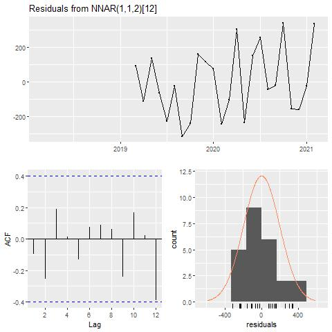

Resíduos da previsão para o produto MO0091 em São Paulo

A Tabela @ref(tab:TABMO0091SP002) apresenta os valores previstos para o ano de 2021.

Previsão de demanda do produto MO0091 para São Paulo

| 03/21 | 04/21 | 05/21 | 06/21 | 07/21 | 08/21 | 09/21 | 10/21 | 11/21 | 12/21 |
| --- | --- | --- | --- | --- | --- | --- | --- | --- | --- |
| 1687.1 | 1805.18 | 1810.17 | 1812.07 | 1884.44 | 1694.45 | 1302.34 | 1604.99 | 1562.71 | 1767.9 |

O gráfico da previsão está apresentado na Figura @ref(fig:MO0091SP004).

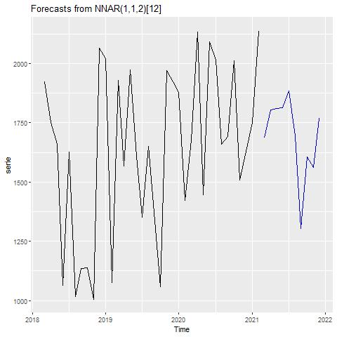

Previsão para o produto MO0091 em São Paulo

### Centro de Tocantins

A Figura @ref(fig:MO0091TO001) apresenta o histórico de vendas para este centro.

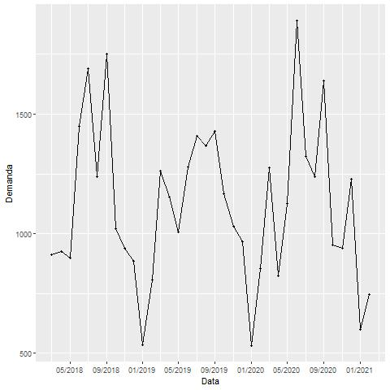

Histório do produto MO0091 em Tocantins

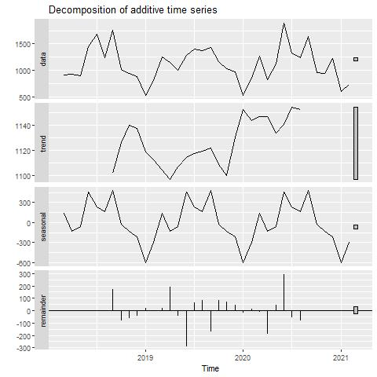

Série decomposta do produto MO0091 em Tocantins

A aplicação dos métodos Suavização Exponencial (SE), ARIMA e Redes Neurais Autoregresivas (RNA) retornou os MAPE’s apresentados na Tabela @ref(tab:TABMO0091TO001).

Comparação entre os modelos

| Método | SE | ARIMA | RNA |
| --- | --- | --- | --- |
| MAPE | 9.15 | 9.86 | 9.35 |

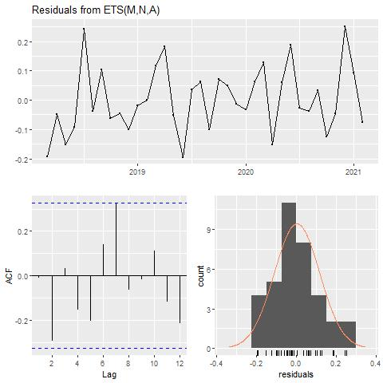

Resíduos da previsão para o produto MO0091 em Tocantins

A Tabela @ref(tab:TABMO0091TO002) apresenta os valores previstos para o ano de 2021.

Previsão de demanda do produto MO0091 para Tocantins

| 03/21 | 04/21 | 05/21 | 06/21 | 07/21 | 08/21 | 09/21 | 10/21 | 11/21 | 12/21 |
| --- | --- | --- | --- | --- | --- | --- | --- | --- | --- |
| 1129.11 | 974.03 | 1061.11 | 1592.61 | 1359.4 | 1285.07 | 1587.77 | 1088.8 | 984.45 | 980.72 |

O gráfico da previsão está apresentado na Figura @ref(fig:MO0091TO004).

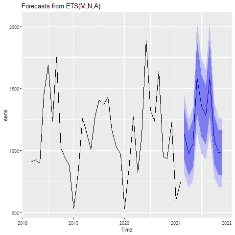

Previsão para o produto MO0091 em Tocantins

### Centro do Amazonas

A Figura @ref(fig:MO0091AM001) apresenta o histórico de vendas para este centro.

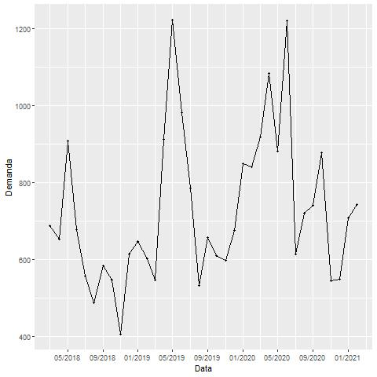

Histório do produto MO0091 no Amazonas

A Figura @ref(fig:MO0091AM002) apresenta a série de forma decomposta em tendência, sazonalidade e restante. Percebe-se pela figura que há uma tendência positiva (aumento da demanda ao longo do tempo), com uma sazonalidade bastante clara.

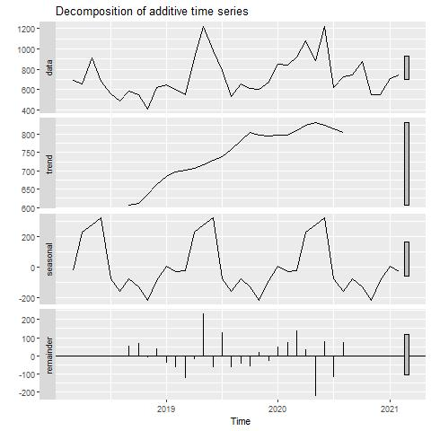

Série decomposta do produto MO0091 no Amazonas

A aplicação dos métodos Suavização Exponencial (SE), ARIMA e Redes Neurais Autoregresivas (RNA) retornou os MAPE’s apresentados na Tabela @ref(tab:TABMO0091AM001).

Comparação entre os modelos

| Método | SE | ARIMA | RNA |
| --- | --- | --- | --- |
| MAPE | 20.03 | 11.24 | 11.25 |

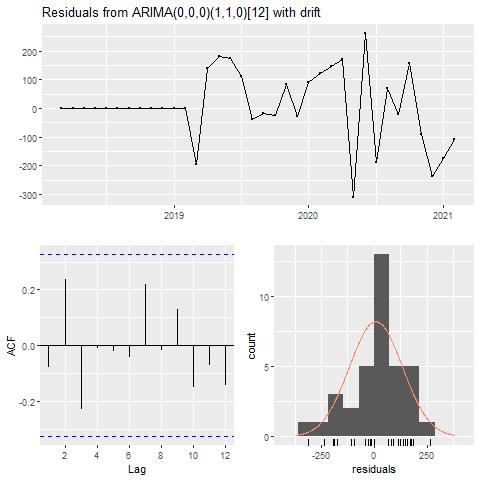

Resíduos da previsão para o produto MO0091 no Amazonas

A Tabela @ref(tab:TABMO0091AM002) apresenta os valores previstos para o ano de 2021.

Previsão de demanda do produto MO0091 para Amazonas

| 03/21 | 04/21 | 05/21 | 06/21 | 07/21 | 08/21 | 09/21 | 10/21 | 11/21 | 12/21 |
| --- | --- | --- | --- | --- | --- | --- | --- | --- | --- |
| 857.01 | 1132.82 | 1214.56 | 1231.73 | 852.98 | 760.45 | 839.24 | 873.1 | 717.42 | 763.12 |

O gráfico da previsão está apresentado na Figura @ref(fig:MO0091AM004).

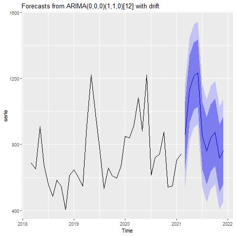

Previsão para o produto MO0091 no Amazonas

## Produto MO1401

Será realizada uma previsão para cada um dos centros de distribuição: São Paulo, Tocantins e Amazonas.

### Centro de São Paulo

A Figura @ref(fig:MO1401SP001) apresenta o histórico de vendas para este centro.

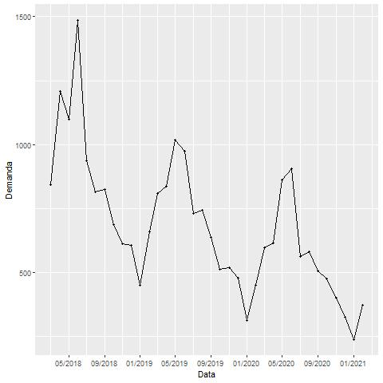

Histório do produto MO1401 em São Paulo

A Figura @ref(fig:MO1401SP002) apresenta a série de forma decomposta em tendência, sazonalidade e restante. Percebe-se pela figura que há uma tendência negativa (queda da demanda ao longo do tempo), com uma sazonalidade bastante clara.

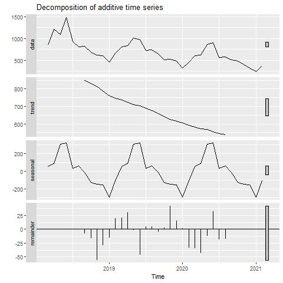

Série decomposta do produto MO1401 em São Paulo

A aplicação dos métodos Suavização Exponencial (SE), ARIMA e Redes Neurais Autoregresivas (RNA) retornou os MAPE’s apresentados na Tabela @ref(tab:TABMO1401SP001).

Comparação entre os modelos

| Método | SE | ARIMA | RNA |
| --- | --- | --- | --- |
| MAPE | 5.75 | 7.73 | 6.37 |

Portanto, por ter o menor MAPE, o método utilizado para a previsão é o de Suavização Exponencial. Ademais, a Figura @ref(fig:MO1401SP003) apresenta a análise de resíduos. Como esperado, os resíduos variam em torno de zero sem tendência positiva ou negativa, o parâmetro ACF (fator de autocorrelação) mostra resultados positivos uma vez que os resíduos não apresentam autocorrelação (as linhas pretas não extrapolam os limites em azul) e os erros apresentam uma característica normal.

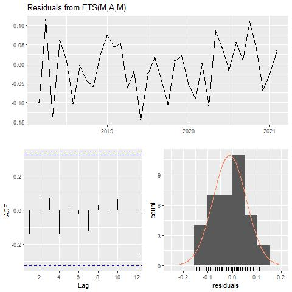

Resíduos da previsão para o produto MO1401 em São Paulo

A Tabela @ref(tab:TABMO1401SP002) apresenta os valores previstos para o ano de 2021.

Previsão de demanda do produto MO1401 para São Paulo

| 03/21 | 04/21 | 05/21 | 06/21 | 07/21 | 08/21 | 09/21 | 10/21 | 11/21 | 12/21 |
| --- | --- | --- | --- | --- | --- | --- | --- | --- | --- |
| 431.94 | 493.07 | 565.47 | 612.52 | 396.51 | 379.52 | 339.67 | 286.75 | 253.18 | 224.73 |

O gráfico da previsão está apresentado na Figura @ref(fig:MO1401SP004).

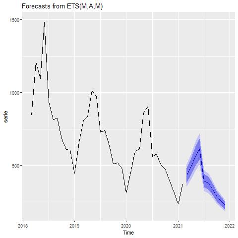

Previsão para o produto MO1401 em São Paulo

### Centro de Tocantins

A Figura @ref(fig:MO1401TO001) apresenta o histórico de vendas para este centro.

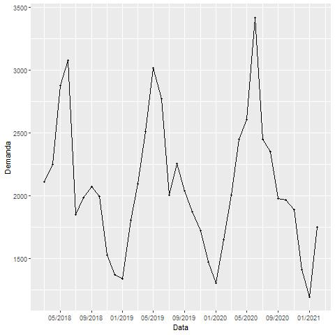

Histório do produto MO1401 em Tocantins

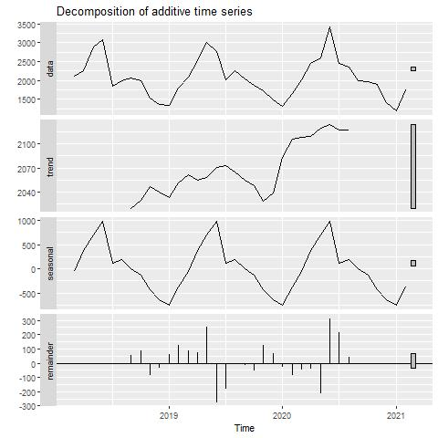

Série decomposta do produto MO1401 em Tocantins

A aplicação dos métodos Suavização Exponencial (SE), ARIMA e Redes Neurais Autoregresivas (RNA) retornou os MAPE’s apresentados na Tabela @ref(tab:TABMO1401TO001).

Comparação entre os modelos

| Método | SE | ARIMA | RNA |
| --- | --- | --- | --- |
| MAPE | 5.16 | 5.15 | 5.1 |

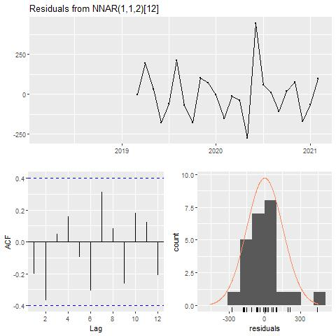

Resíduos da previsão para o produto MO1401 em Tocantins

A Tabela @ref(tab:TABMO1401TO002) apresenta os valores previstos para o ano de 2021.

Previsão de demanda do produto MO1401 para Tocantins

| 03/21 | 04/21 | 05/21 | 06/21 | 07/21 | 08/21 | 09/21 | 10/21 | 11/21 | 12/21 |
| --- | --- | --- | --- | --- | --- | --- | --- | --- | --- |
| 2034.01 | 2460.32 | 2865.02 | 3099.34 | 2683.53 | 2526.25 | 2093.12 | 2014.56 | 1955.93 | 1576.73 |

O gráfico da previsão está apresentado na Figura @ref(fig:MO1401TO004).

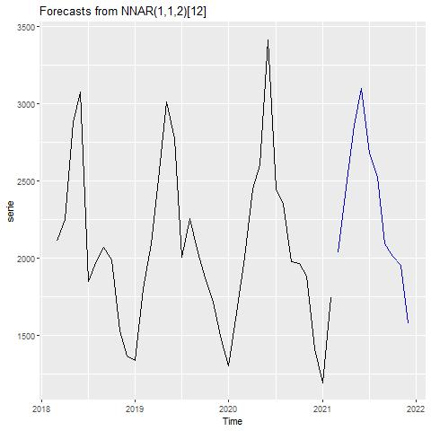

Previsão para o produto MO1401 em Tocantins